# Sperm whale teeth data TFM

Sperm whale teeth, cut in half longitudinally, are used for determining their age from the dentine growth layers on the cut surface. In addition, if we take samples from different growth layers, we can analyze stable isotope values in each of them and see how they are changing through the animal’s lifetime to determine changes in habitat and diet.

However, after simply cutting the tooth in half, the growth layer visibility is very poor because the surface is very smooth. To be able to determine age from the growth lines, scientists usually take one of the half-sections and treat it with formic acid to achieve a more pronounced surface relief. On top, they use a graphite pencil to cover the protruding parts of the surface with graphite, this way improving the growth layer visibility even more.

Usually, scientists used this treated half-section to determine the age and distinguish growth layers, but they used the non-treated half-section for sampling instead (because they thought treatment could affect the stable isotope values). However, when sampling from a half-section with poor growth layer visibility, obviously there are higher chances of error.

So what we want to do is investigate whether the treatments actually affect the stable isotope values in a way that does not allow the use of a treated half-section for sampling.

We want to see the difference between:

1. Non-treated samples VS Treated samples without graphite (clean)
2. Treated samples with graphite (not clean) VS Treated samples without graphite (clean)

This way we want to find out if:

1. We can only use the **non-treated** half-section for sampling
2. We can use the **treated half-section, but without the graphite layer** ( growth layer visibility better than a but worse than c)
3. We can use the **treated + graphite covered half-section** (ideal option, because the visibility is highest)

What was done in the lab:

1. I took 30 sperm whale teeth cut in half longitudinally. One half was not treated, the other half was treated and covered with graphite.
2. I sampled the dentine powder (using a drill) from the same (hopefully) growth layer in both half-sections of the teeth. This way I got 30 **non-treated** samples and 30 **treated+graphite** samples.
3. I then washed away the graphite from the treated+graphite half-section, and sampled it once again, getting 30 **treated samples without graphite**.
4. I received the carbon (C) and nitrogen (N) stable isotope values in all of these samples after using a mass spectrometer. Time to analyze the results ->

```r
teeth_data <- read.csv("Samples-Laura-CLEAN-FOR-R.csv")
names(teeth_data)[1] <- 'treated_gr_N'
names(teeth_data)[2] <- 'treated_gr_C'
```

```r
library(dplyr)
library(ggplot2)
```

## DATA EXPLORATION

Boxplots of all the variables (scaled, because N and C values differ a lot)

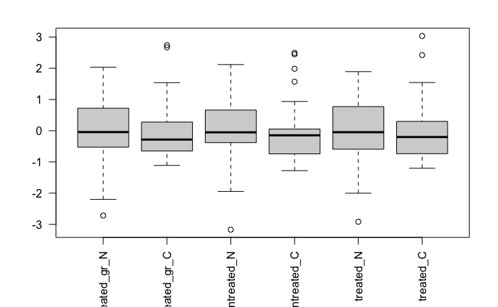

```r
boxplot(scale(teeth_data), las =2)
```

Normality plots

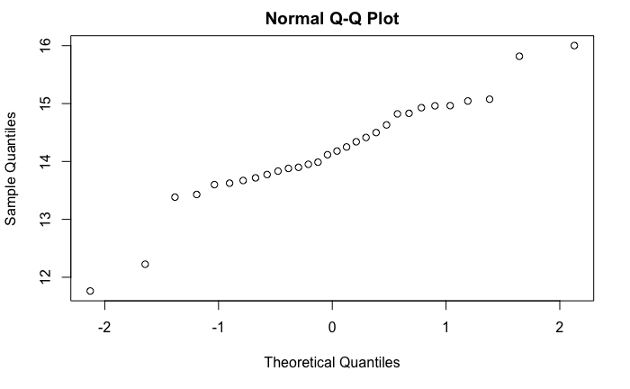

```r
qqnorm(teeth_data$treated_gr_N)
```

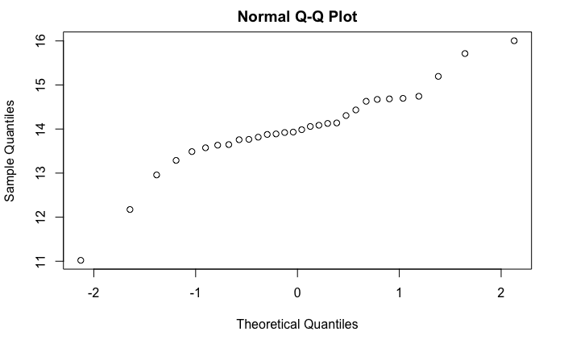

```r
qqnorm(teeth_data$nontreated_N)
```

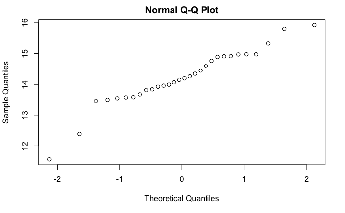

```r
qqnorm(teeth_data$treated_N)
```

All nitrogen data looks normal, at least visually. Let’se see for carbon:

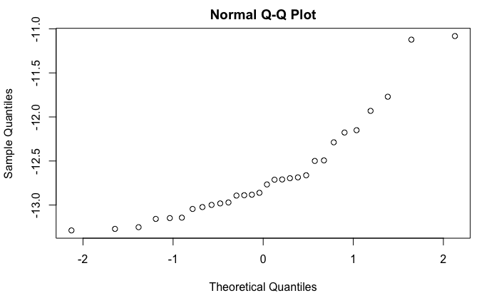

```r
qqnorm(teeth_data$treated_gr_C)
```

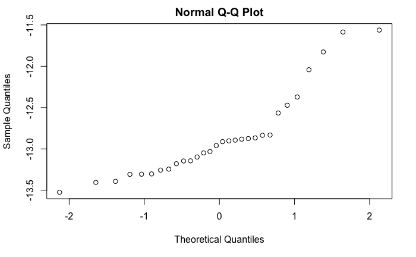

```r
qqnorm(teeth_data$nontreated_C)
```

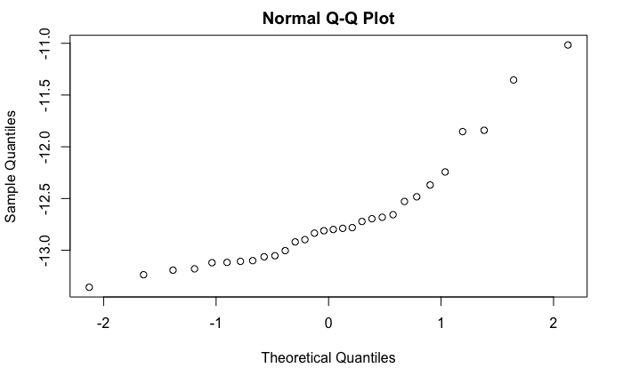

```r
qqnorm(teeth_data$treated_C)
```

C data doesn’t look completely normal. Let’s test it for normality:

```r
shapiro.test(teeth_data$treated_gr_C)
```

```
    Shapiro-Wilk normality test

data:  teeth_data$treated_gr_C
W = 0.85054, p-value = 0.0006363
```

```r
shapiro.test(teeth_data$treated_C)
```

```
    Shapiro-Wilk normality test

data:  teeth_data$treated_C
W = 0.83983, p-value = 0.0003825
```

```r
shapiro.test(teeth_data$nontreated_C)
```

```
    Shapiro-Wilk normality test

data:  teeth_data$nontreated_C
W = 0.85664, p-value = 0.0008569
```

As we can see, **all of the C data does not follow a normal distribution**, so for these ones we will use non-parametric tests

```r
shapiro.test(teeth_data$nontreated_N)
```

```
    Shapiro-Wilk normality test

data:  teeth_data$nontreated_N
W = 0.91692, p-value = 0.02233
```

*The non-treated N data also do not follow a normal distribution… So maybe we can use non-parametric tests for all of them?..*

Correlation plots - just out of curiosity

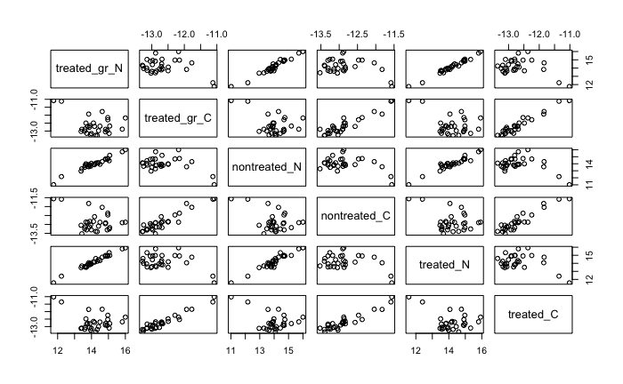

```r
plot(teeth_data)
```

## Differences between samples

Now we want to know if the samples with different treatments differ significantly from each other. I thought to use the Paired Samples Wilcoxon signed rank test (non-parametric) for all of them - not sure if this is the best decision but I guess it should serve us.

1. Does the acid treatment have a visible effect on C and N isotope values? To answer this, we are comparing **non-treated samples** (boxplot 1) with **treated samples (without graphite)** (boxplot 2).

```r
only_C_data <- teeth_data[,c(4,6,2)]
only_N_data <- teeth_data[,c(3,5,1)]
```

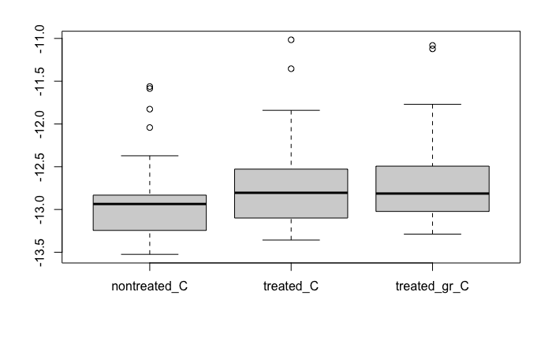

```r
boxplot(only_C_data)
```

Let’s compare non-treated sample C values with treated sample C values (without graphite) using a Paired Samples Wilcoxon Signed-rank test (non-parametric)

```r
wilcox.test(teeth_data$nontreated_C, teeth_data$treated_C, paired=TRUE)
```

```
    Wilcoxon signed rank exact test

data:  teeth_data$nontreated_C and teeth_data$treated_C
V = 52, p-value = 7.057e-05
alternative hypothesis: true location shift is not equal to 0
```

The p is less than 0,05 for this one, so **the acid treatment does alter C values significantly.**

What about N?

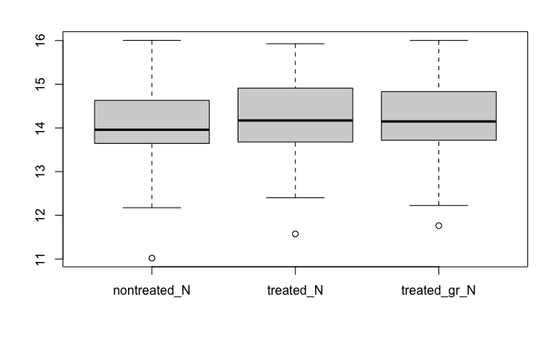

```r
boxplot(only_N_data)
```

```r
wilcox.test(teeth_data$nontreated_N, teeth_data$treated_N, paired=TRUE)
```

```
    Wilcoxon signed rank exact test

data:  teeth_data$nontreated_N and teeth_data$treated_N
V = 70, p-value = 0.0004601
alternative hypothesis: true location shift is not equal to 0
```

The p is less than 0,05 for this one too, so **the acid treatment does alter N values significantly** as well.

2. Does graphite have a visible effect on C and N isotope values?

is this step necessary? If I did not misunderstand the process the acid treatment and graphite are sequential phases with the former being run ahead of the latter. In such case and given that our earlier wilcox test altered the C and N values already, the test on graphite would then be irrelevant? .

To see this we are comparing treated samples without a graphite layer vs treated samples with a graphite layer.

First for C:

```r
wilcox.test(teeth_data$treated_C, teeth_data$treated_gr_C, paired=TRUE)
```

```
    Wilcoxon signed rank exact test

data:  teeth_data$treated_C and teeth_data$treated_gr_C
V = 166, p-value = 0.1772
alternative hypothesis: true location shift is not equal to 0
```

The p value is larger than 0,05, this means that **graphite seems to not alter the C values significantly.** (this would mean if we were to use the treated half-section of the tooth in the future, cleaning off the graphite is unnecesarry. We could leave it there and have better visibility of growth layers this way.)

What about N?

```r
wilcox.test(teeth_data$treated_N, teeth_data$treated_gr_N, paired=TRUE)
```

```
    Wilcoxon signed rank exact test

data:  teeth_data$treated_N and teeth_data$treated_gr_N
V = 264, p-value = 0.5291
alternative hypothesis: true location shift is not equal to 0
```

Same as with C, the p value is larger than 0,05, this means that **graphite seems to not alter the N values significantly.** So at this point I think we can leave the graphite data behind as it became insignificant.

## Scatterplots

Now we would like to find out if the differences between treated and non-treated samples are constant. If they are constant, we could use the treated half-sections after deriving a correction factor (a model) and applying it to determine the real values.

Maybe scatterplots could give us some idea?

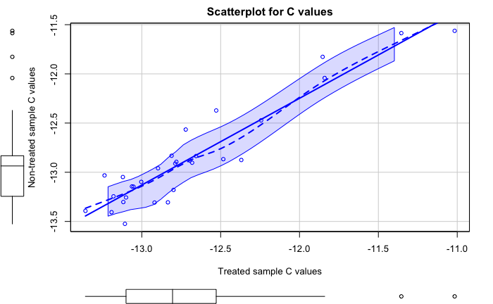

```r
library(car)
scatterplot(nontreated_C ~ treated_C, data=teeth_data,
   xlab="Treated sample C values", ylab="Non-treated sample C values",
   main="Scatterplot for C values")
```

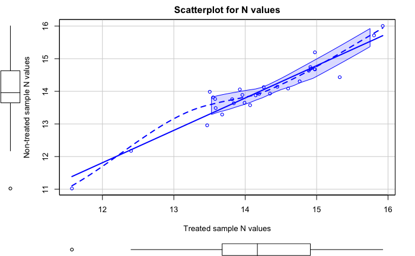

```r
scatterplot(nontreated_N ~ treated_N, data=teeth_data,
   xlab="Treated sample N values", ylab="Non-treated sample N values",
   main="Scatterplot for N values")
```

## Dispersion of differences

Maybe we should take a look at how dispersed are the differences for these values. For this we could create new variables by subtracting one variable from another (values before treatment - values after treatment):

```r
teeth_data$difC <- teeth_data$nontreated_C - teeth_data$treated_C
teeth_data$difN <- teeth_data$nontreated_N - teeth_data$treated_N
```

```r
C_difference <- teeth_data[,c(7)]
N_difference <- teeth_data[,c(8)]
```

```r
sd(C_difference)
```

```
[1] 0.194227
```

```r
sd(N_difference)
```

```
[1] 0.284966
```

```r
summary(C_difference)
```

```
   Min. 1st Qu.  Median    Mean 3rd Qu.    Max.
-0.5462 -0.2305 -0.1678 -0.1659 -0.0633  0.2039
```

```r
summary(N_difference)
```

```
    Min.  1st Qu.   Median     Mean  3rd Qu.     Max.
-0.89027 -0.37738 -0.24373 -0.20597 -0.07623  0.48236
```

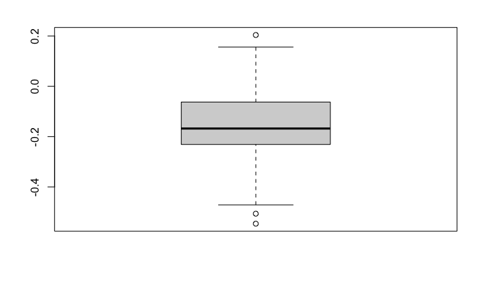

```r
boxplot(C_difference)
```

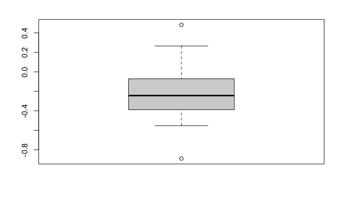

```r
boxplot(N_difference)
```

# Trying out a model

Just out of curiosity, I am trying to apply a linear regression model to this data.

```r
mC <- lm (treated_C ~ nontreated_C, teeth_data)
summary(mC)
```

```
Call:
lm(formula = treated_C ~ nontreated_C, data = teeth_data)

Residuals:
     Min       1Q   Median       3Q      Max
-0.37085 -0.10361  0.00083  0.07050  0.38753

Coefficients:
             Estimate Std. Error t value Pr(>|t|)
(Intercept)   0.09345    0.90793   0.103    0.919
nontreated_C  0.99436    0.07055  14.095 3.06e-14 ***
---
Signif. codes:  0 ‘***’ 0.001 ‘**’ 0.01 ‘*’ 0.05 ‘.’ 0.1 ‘ ’ 1

Residual standard error: 0.1976 on 28 degrees of freedom
Multiple R-squared:  0.8765,    Adjusted R-squared:  0.8721
F-statistic: 198.7 on 1 and 28 DF,  p-value: 3.063e-14
```

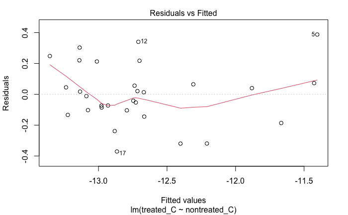

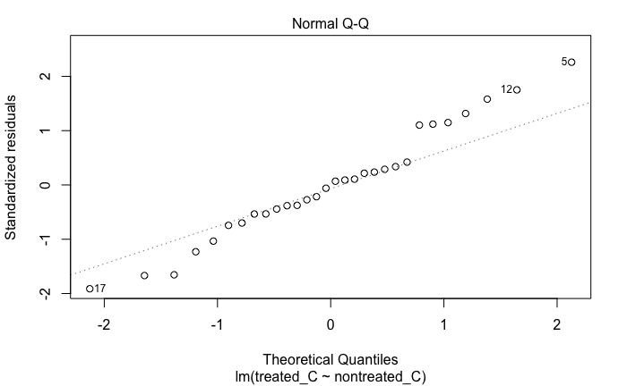

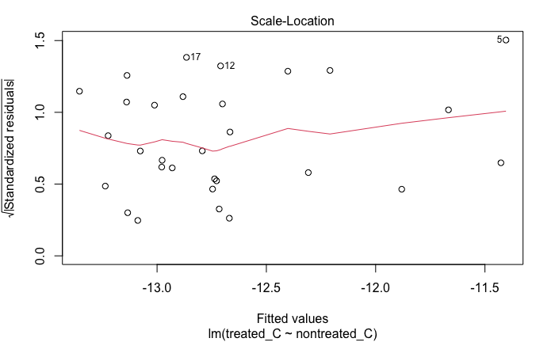

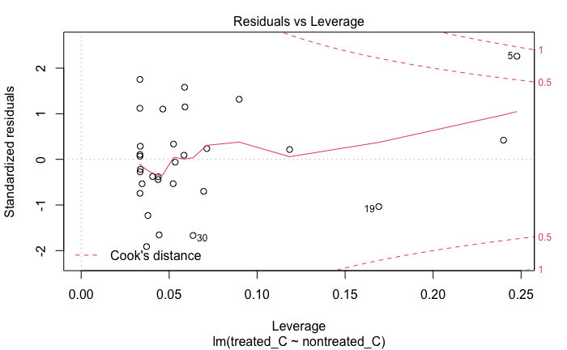

```r
plot(mC)
```

In the first plot it looks like the residuals are pretty dispersed… Not good? Quite the contrary. It is actually a very good one as most points can be squared in a rectangle which longer sides run parallel to the x-axis.

Trying N now:

Look at the p-value! It is amazingly significant. It is 0.000000000000000443, this is a pretty strong indication that the linear regression model is a good fit. In addition look at the Rsquare which explains how much the variance is explained by our model, that is to say, SSE/SSR. This is saying that 90% of the variance is explained by the model itself. In other words, our regression model is capable of explaining most of the observations with a marginal error. Good for you!

```r
mN <- lm (treated_N ~ nontreated_N, teeth_data)
summary(mN)
```

```
Call:
lm(formula = treated_N ~ nontreated_N, data = teeth_data)

Residuals:
     Min       1Q   Median       3Q      Max
-0.69013 -0.14174  0.05581  0.13388  0.72028

Coefficients:
             Estimate Std. Error t value Pr(>|t|)
(Intercept)   1.38802    0.77034   1.802   0.0824 .
nontreated_N  0.91561    0.05488  16.685 4.43e-16 ***
---
Signif. codes:  0 ‘***’ 0.001 ‘**’ 0.01 ‘*’ 0.05 ‘.’ 0.1 ‘ ’ 1

Residual standard error: 0.2785 on 28 degrees of freedom
Multiple R-squared:  0.9086,    Adjusted R-squared:  0.9053
F-statistic: 278.4 on 1 and 28 DF,  p-value: 4.43e-16
```

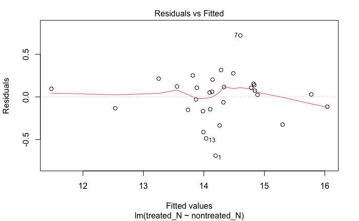

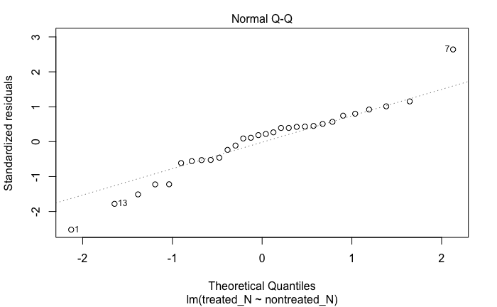

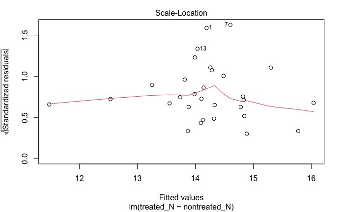

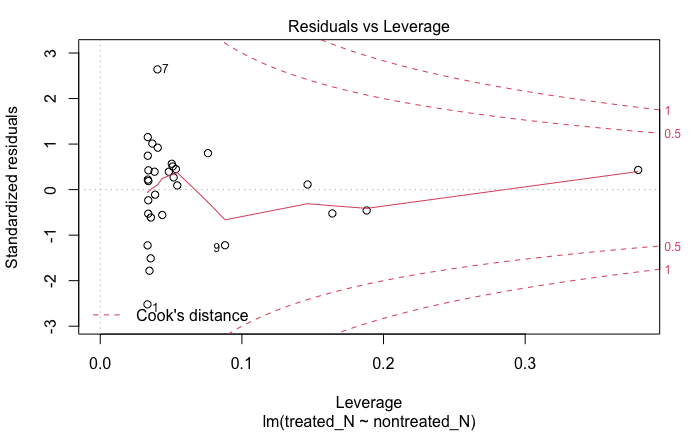

```r
plot(mN)
```

In the first graph some residuals are dispersed too… Not good again? I wonder if it would be better if we removed the outliers that are seen in the boxplots of differences.

## Removing outliers

```r
teeth_sin_outliers <- teeth_data %>% slice(-c(7, 1, 17, 5, 12))
```

```r
mCsin <- lm (treated_C ~ nontreated_C, teeth_sin_outliers)
summary(mCsin)
```

```
Call:
lm(formula = treated_C ~ nontreated_C, data = teeth_sin_outliers)

Residuals:
     Min       1Q   Median       3Q      Max
-0.26595 -0.08844 -0.02197  0.12771  0.28476

Coefficients:
             Estimate Std. Error t value Pr(>|t|)
(Intercept)  -1.18361    0.83434  -1.419    0.169
nontreated_C  0.89702    0.06469  13.865 1.17e-12 ***
---
Signif. codes:  0 ‘***’ 0.001 ‘**’ 0.01 ‘*’ 0.05 ‘.’ 0.1 ‘ ’ 1

Residual standard error: 0.1579 on 23 degrees of freedom
Multiple R-squared:  0.8931,    Adjusted R-squared:  0.8885
F-statistic: 192.2 on 1 and 23 DF,  p-value: 1.175e-12
```

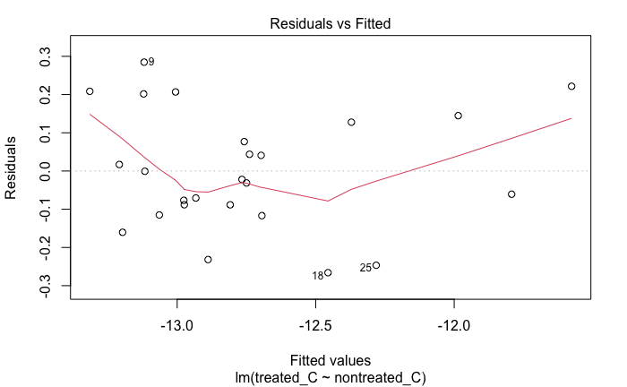

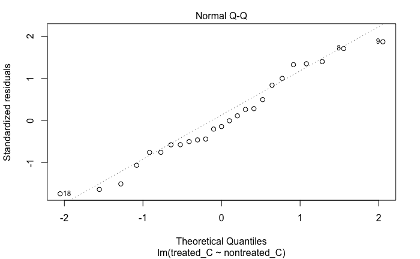

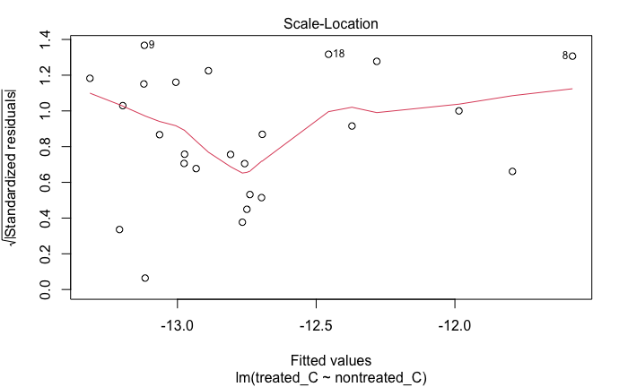

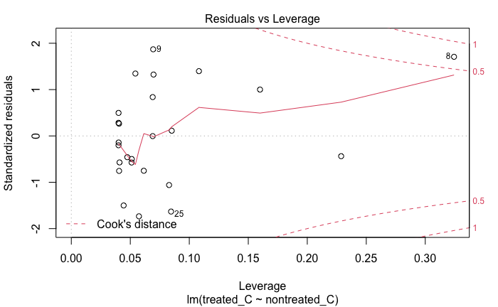

```r
plot(mCsin)
```

Umm.. Is this considered better?

```r
mNsin <- lm (treated_N ~ nontreated_N, teeth_sin_outliers)
summary(mNsin)
```

```
Call:
lm(formula = treated_N ~ nontreated_N, data = teeth_sin_outliers)

Residuals:
     Min       1Q   Median       3Q      Max
-0.47831 -0.13675  0.05912  0.14083  0.31957

Coefficients:
             Estimate Std. Error t value Pr(>|t|)
(Intercept)   1.12029    0.88471   1.266    0.218
nontreated_N  0.93434    0.06291  14.851 2.82e-13 ***
---
Signif. codes:  0 ‘***’ 0.001 ‘**’ 0.01 ‘*’ 0.05 ‘.’ 0.1 ‘ ’ 1

Residual standard error: 0.2224 on 23 degrees of freedom
Multiple R-squared:  0.9056,    Adjusted R-squared:  0.9015
F-statistic: 220.6 on 1 and 23 DF,  p-value: 2.818e-13
```

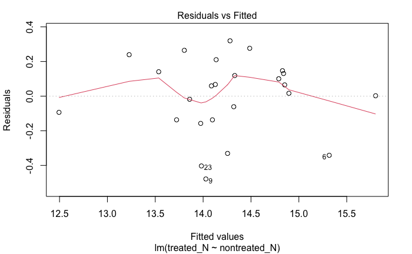

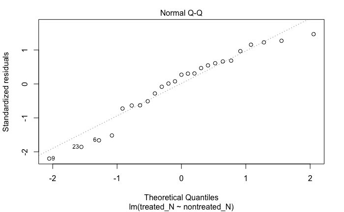

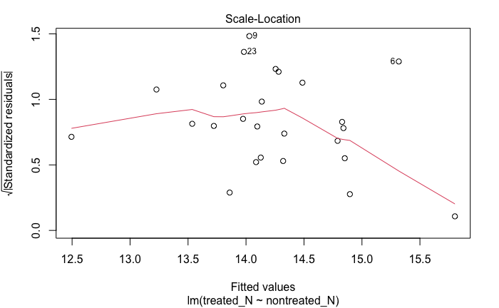

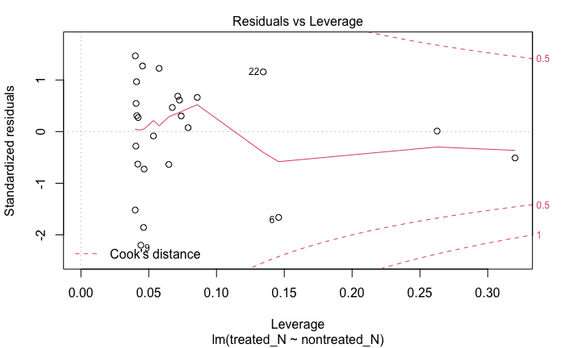

```r
plot(mNsin)
```

Not sure if this way the model got better really…

## Heteroscedasticity test

Here I tried some test I found for heteroscedasticity (Breusch-Pagan test). Not sure if it fits well here, but…

```r
library(lmtest)
bptest(mN)
```

```
    studentized Breusch-Pagan test

data:  mN
BP = 0.079953, df = 1, p-value = 0.7774
```

```r
bptest(mC)
```

```
    studentized Breusch-Pagan test

data:  mC
BP = 1.3178, df = 1, p-value = 0.251
```

## Just some additional ggplots

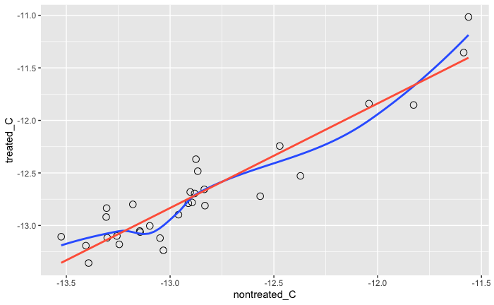

```r
ggplot(teeth_data, aes(nontreated_C, treated_C)) +
  geom_point(shape = 21, size = 3) +
  geom_smooth(se = FALSE) +
  geom_smooth(method = lm, col = "tomato", se = FALSE)
```

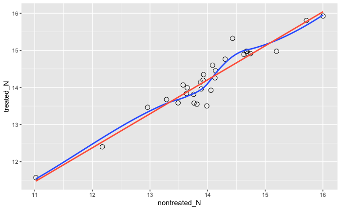

```r
ggplot(teeth_data, aes(nontreated_N, treated_N)) +
  geom_point(shape = 21, size = 3) +
  geom_smooth(se = FALSE) +
  geom_smooth(method = lm, col = "tomato", se = FALSE)
```

## Conclusions

I think we are done with linear regression. It is pretty clear that there is a relationship.

## Improvements

1. Contextualise the plots by adding meaningful titles and adding axis names for those that have them missing
2. Perhaps doing a one-way Anova in order to determine that the graphite dust doesn’t alter the linear relationship between non-treated vs treated. Given that Anova looks at explaining the linear relationship between variables with the less complexity possible, I would expect that the non-treated vs treated-acid-only would be enough. In other words, that Anova will tell us to get rid of the graphite phase because it does not add any real substantial value, only complexity. Reading it from another angle, that would mean that we can correlate safely non-treated vs treated-with-acid-and-graphite. That would also be backed up by the fact that when we checked whether graphite altered the values of C and N, the test result was that it didn’t. It is a transitive relationship if A -> B and B -> C –> A –> C. In our case would be if Non-Treated vs Treated-Acid_only has a relationship and Treated-Acid-Only vs Treated-Acid-Graphite changes nothing then Non-Treated vs Treated-Acid-Graphite do have too a linear relationship. Anova would tell us exactly that I believe?

I could give it a go to Anova myself if you like - primarily I would just ensure that we aren’t overengineering it.